## Overview

This application was designed for Developing Data Products as part of the Coursera Data Science Speicalization Course. In 1974, Motor Trend US Magazine collected data (11 variable) on 32 automobiles. The Data for prediction was extracted from here . Using the application above and using the data provided in mtcars, the cost of gasoline incurred traveling some distance driving one of the 32 vehicles reported in 1974, using the national average gasoline price (as of 25th of February, 2018) of $2.523/gal can be calculated (other prices can be input as well). The variables studied in 1974 has been stated ,how the data output would look in R will be shown, and a matrix plot of variables that are used in the app is shown in the presentation.

The first part of the assignment to create a Shiny application can be found here: https://subramanyankp.shinyapps.io/Subbu-Cars01/

The second part of the assigment to prepare a reproducible pitch presentation about the application can be found here:

https://github.com/SubramanyanKP/Peer-graded-Assignment-Course-Project-Shiny-Application-and-Reproducible-Pitchitch

## Data and Variables Given :

- [, 1] mpg - Miles/(US) gallon.
- [, 2] cyl - Number of cylinders.
- [, 3] disp - Displacement (cu.in.).
- [, 4] hp - Gross horsepower.
- [, 5] drat - Rear axle ratio.
- [, 6] wt - Weight (1000 lbs)
- [, 7] qsec - quarter (1/4) mile time.
- [, 8] vs - V/S.
- [, 9] am - Transmission (0 = automatic, 1 = manual).
- [,10] gear - Number of forward gears.
- [,11] carb - Number of carburetors.

## Data output in R:

We can use head(mtcars) to view the first 6 lines of the data in R.

```r
head(mtcars)
```

```
##                    mpg cyl disp  hp drat    wt  qsec vs am gear carb
## Mazda RX4         21.0   6  160 110 3.90 2.620 16.46  0  1    4    4
## Mazda RX4 Wag     21.0   6  160 110 3.90 2.875 17.02  0  1    4    4
## Datsun 710        22.8   4  108  93 3.85 2.320 18.61  1  1    4    1
## Hornet 4 Drive    21.4   6  258 110 3.08 3.215 19.44  1  0    3    1
## Hornet Sportabout 18.7   8  360 175 3.15 3.440 17.02  0  0    3    2
## Valiant           18.1   6  225 105 2.76 3.460 20.22  1  0    3    1
```

## Plotting data:

The matrix plot below focuses on only Miles/gallon (mpg), Number of cylinders (cyl), Weight in 1000lbs (wt), and type of transmission (am) among the 11 variables available in the data .

Now, to produce the table we need to use: pairs(~mpg+cyl+wt+am, data=mtcars).

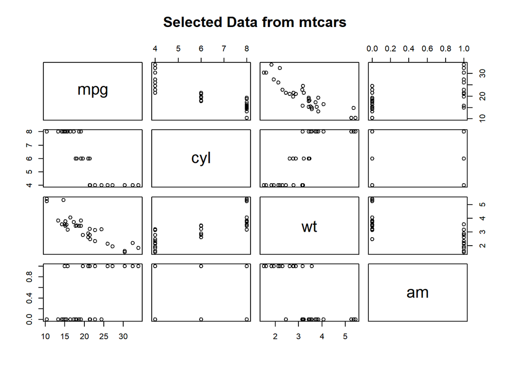

```r
pairs(~mpg+cyl+wt+am, data=mtcars, main= "Selected Data from mtcars")
```